# sRedList report - Camponotus latangulus

sRedList v1.6

Performed by victor.cazalis

01/04/2026

An assessment has been completed on the sRedList platform for the species *Camponotus latangulus* on the 01/04/2026. All outputs from this assessment are reported in the .csv and .shp files that were downloaded at the end of the assessment and they can be pushed on SIS through SIS Connect. This report is here to detail how these results were obtained (e.g., which parameters were used on the sRedList platform), to provide context around results (e.g., saving the different maps created on the platform), and help communication among assessors and with reviewers.

## Step 1: Distribution

You used the sRedList platform to create a distribution map of your species from occurrence records.

### Download data

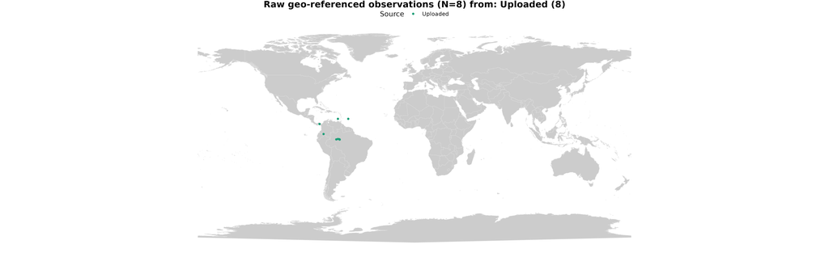

### Filter data

To filter occurrence records, the platform offers some automated filters from the CoordinateCleanR package (see sRedList documentation for more information); you chose to apply those filters in your assessment. In addition, you excluded all records made before 1900 (but keeping records that do not have year information). You also excluded all records with coordinates uncertainty higher than 10km (but keeping records that do not have coordinate uncertainty information).

Occurrence records are displayed in the leaflet map below (valid records in yellow and excluded records in purple; you can click on observation get more information and exclusion reason, check the sRedList documentation for more details). They are also available in the interactive table below (invalid records are displayed in the table with a non-empty ‘Invalid_reason’ column).

[interactive chart not shown]

| Longitude | Latitude | ID | Source_type | Invalid_reason | sci_name | presence | origin | seasonal | compiler | yrcompiled | citation | dec_lat | dec_long | spatialref | subspecies | subpop | data_sens | sens_comm | year | source_reference | catalog_no | dist_comm | island | tax_comm | Link | country | .pres |
| --- | --- | --- | --- | --- | --- | --- | --- | --- | --- | --- | --- | --- | --- | --- | --- | --- | --- | --- | --- | --- | --- | --- | --- | --- | --- | --- | --- |
| -62.35624 | -4.232265 | Uploaded_1 | Uploaded |  | Camponotus latangulus |  |  |  |  |  |  | -4.232265 | -62.35624 |  |  |  |  |  | 2017 | Carvajal et al. 2019 |  |  |  |  | Link |  | TRUE |
| -64.96543 | -4.365413 | Uploaded_2 | Uploaded |  | Camponotus latangulus |  |  |  |  |  |  | -4.365413 | -64.96543 |  |  |  |  |  | 2017 | Carvajal et al. 2019 |  |  |  |  | Link |  | TRUE |
| -62.12364 | -4.501321 | Uploaded_3 | Uploaded |  | Camponotus latangulus |  |  |  |  |  |  | -4.501321 | -62.12364 |  |  |  |  |  | 2017 | Mulaomerovi? and Glöer |  |  |  |  | Link |  | TRUE |
| -63.59648 | -4.021563 | Uploaded_4 | Uploaded |  | Camponotus latangulus |  |  |  |  |  |  | -4.021563 | -63.59648 |  |  |  |  |  | 2017 | Carvajal et al. 2019 |  |  |  |  | Link |  | TRUE |
| -55.03215 | 12.71326 | Uploaded_5 | Uploaded |  | Camponotus latangulus |  |  |  |  |  |  | 12.71326 | -55.03215 |  |  |  |  |  | 2023 | Mulaomerovi? and Glöer |  |  |  |  | Link |  | TRUE |
| -63.59648 | 12.71326 | Uploaded_6 | Uploaded |  | Camponotus latangulus |  |  |  |  |  |  | 12.71326 | -63.59648 |  |  |  |  |  | 2017 | Cazalis, 2023 |  |  |  |  | Link |  | TRUE |
| -75.51346 | 0.10123 | Uploaded_7 | Uploaded |  | Camponotus latangulus |  |  |  |  |  |  | 0.10123 | -75.51346 |  |  |  |  |  | 2014 | Parque Nacional Natural La Pay... |  |  |  |  | Link |  | TRUE |
| -78.90321 | 8.39632 | Uploaded_8 | Uploaded |  | Camponotus latangulus |  |  |  |  |  |  | 8.39632 | -78.90321 |  |  |  |  |  | 1903 | Amaro and Rousseau, 1903 |  |  |  |  | Link |  | TRUE |

After applying these filters, your point range map included 8 occurrence records.

[figure not shown]

### Create range map

To create a polygon range map, you chose first to draw the minimum convex polygon around occurrence records.

The range map created at this step is:

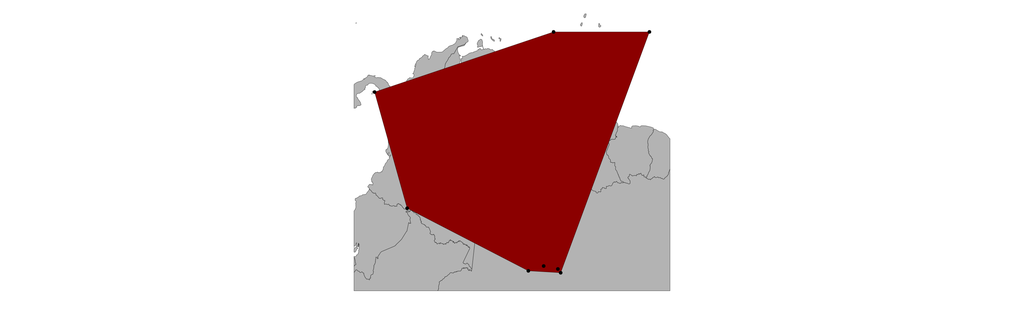

[figure not shown]

You then filtered the distribution, keeping only presence codes 1,2, origin codes 1,2, and seasonal codes 1,2. This distribution was used for quantitative analyses (to calculate EOO, AOO, trends in AOH, fragmentation and trends in remote-sensed products) and was:

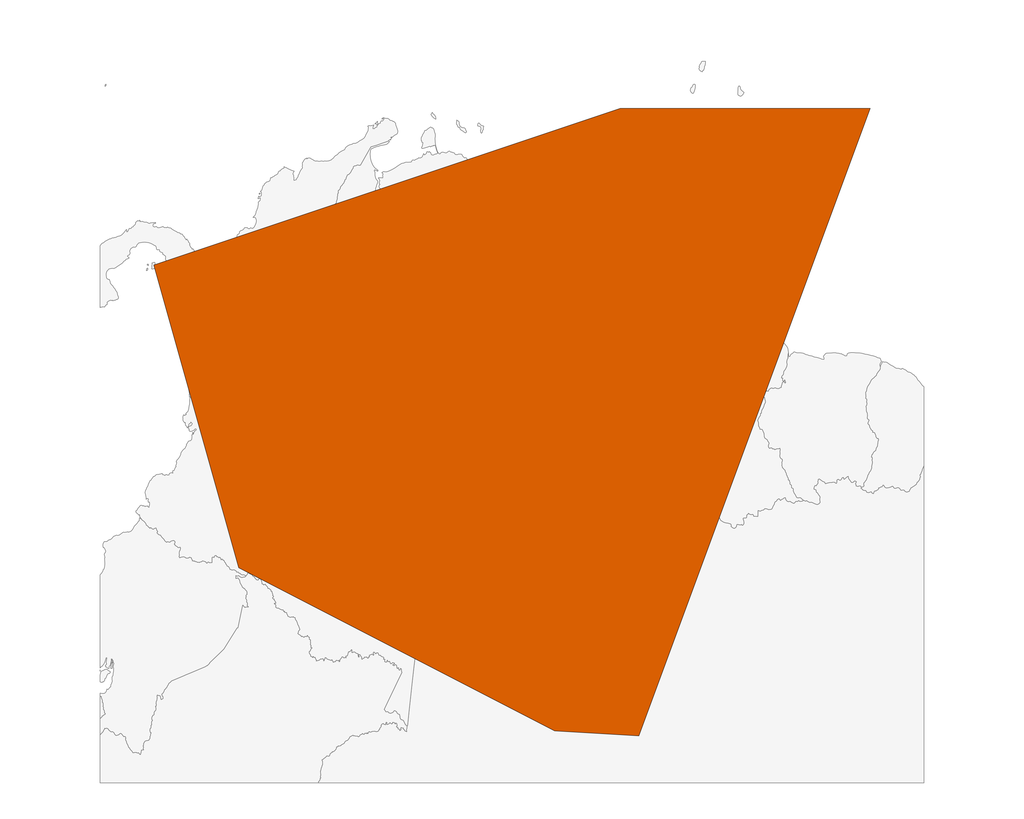

## Step 2: Countries of occurrence

This step was not performed on the platform.

## Step 3: Extent of occurrence

This step was not performed on the platform.

## Step 4: Area of Habitat

As you have drawn distribution maps from occurrence points, we calculate the species known area of occupancy based on these records. Note that this is a very conservative estimate of the area of occupancy as it is only based on known occurrences (or even just a sample if there were more than 2000 records in GBIF). The value of known area of occupancy is 32km2.

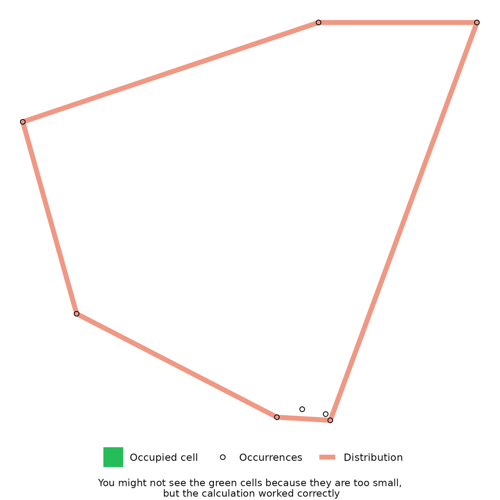

### Habitat preferences

[figure not shown]

The habitat preferences used to map Area of Habitat were:

[output not shown]

Note that the major importance and seasonality fields are left empty from the habitats.csv file, so you might want to complete that information in SIS later.

### Elevation preferences

[figure not shown]

### Density

You did not provide a density value and thus did not estimate population size.

### AOH calculation

The calculated Area of Habitat has a value of 1,890,000 km2.

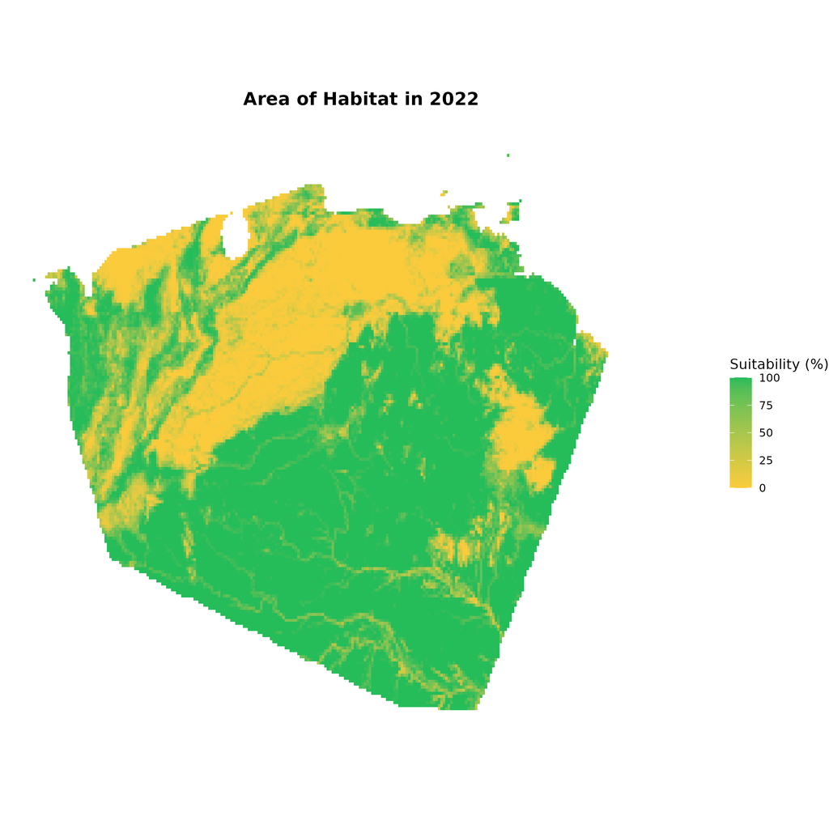

When rescaled at a 2x2km grid, this provides a value of 2,630,904 km2; this value can be used (if you trust the map) as an upper bound of area of occupancy if you consider likely that all the mapped suitable habitat is occupied by the species. If you know part of it is not occupied, you might want to reduce this estimate. Note that, as your species has a large range, the platform used a simplified version of land-cover which may lead the upper bound of AOO to be slightly overestimated.

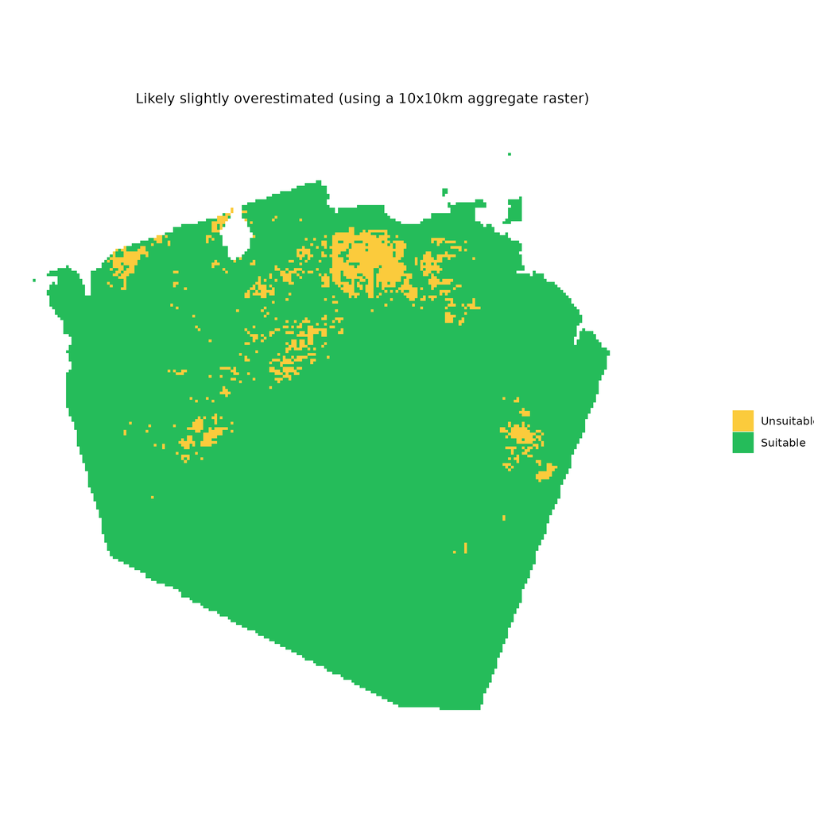

### Model and point prevalence

Model prevalence (the proportion of suitable AOH grid cells within the distribution) was 69%. Point prevalence (the proportion of occurrence records that are found within the AOH) was 50%.

## Step 5: Trends in Area of Habitat

This step was not performed on the platform.

## Step 6: Fragmentation

This step was not performed on the platform.

## Step 7: Trends in remote-sensing products

Trends in some remote-sensing products have been calculated. You can check the sRedList documentation to know more on the products we map.

You mapped and calculated trends in Forest Cover using Global Forest Change rasters.

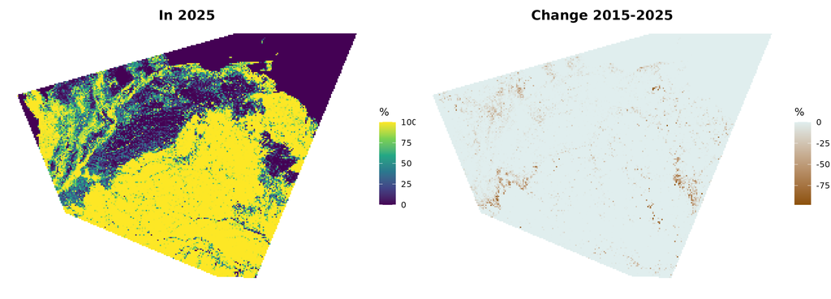

|  | Value |
| --- | --- |
| Current value | 60 % (1941596 km2) |
| Absolute trends | -47524.8 km2 |
| Relative trends | -2.4 % |
| Time-window | 2015-2025 |

[figure not shown]

## Step 8: Summary and assign categories

After the summary step, these are the parameters that are included in the final output allfields.csv:

| Variable | Value |
| --- | --- |
| AOO.justification | The area of occupancy was estimated on the sRedList platform. Its lower bound (32km2) was estimated as the area of 2x2km grid cells intersecting with occurrence records (8 occurrence records were retr… |
| AOO.range | 32-2630904 |
| ElevationLower.limit | 0 |
| ElevationUpper.limit | 5262 |
| GenerationLength.range | 1 |
| NoThreats.noThreats | false |
| SevereFragmentation.isFragmented | No |
| ThreatsUnknown.value | false |
| internal_taxon_id | 10103121 |
| internal_taxon_name | Camponotus latangulus |

These parameters lead to the following Red List criteria application (note though that this is just for visualisation and will not be pushed to SIS):

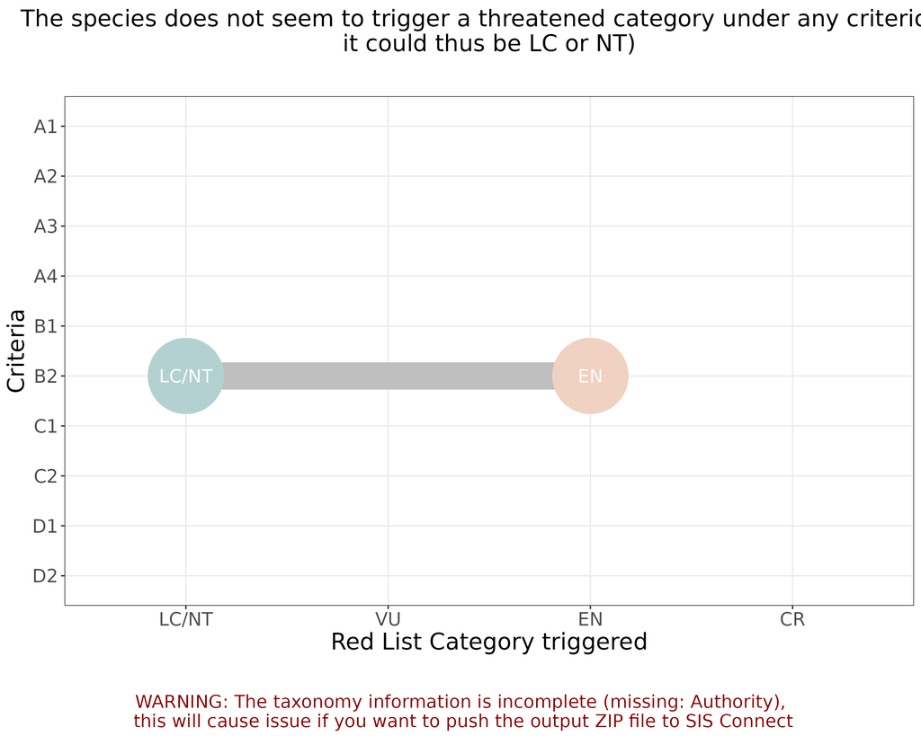

You decided to include the following files in the final ZIP folder: sRedList files (report and outlog csv file), general SIS files (allfields.csv, assessments.csv, references.csv, taxonomy.csv), list of habitat preferences for SIS (habitats.csv), polygon range map shapefile (formatted as required for published assessments), occurrence records (formatted as required for published assessments).

Thank you for using sRedList! You can now either go to SIS and paste the parameters calculated here that you find interesting, or use the ZIP file to push your assessment to SIS Connect.